# Part I - Fordgobike

## Introduction

This data set includes information about individual rides made in a bike-sharing system covering the greater San Francisco Bay area.

## Preliminary Wrangling

```python
# import all packages and set plots to be embedded inline
import numpy as np
import pandas as pd
import seaborn as sb
import matplotlib.pyplot as plt
import calendar
import math
import time
import datetime

%matplotlib inline
```

> Load in your dataset and describe its properties through the questions below. Try and motivate your exploration goals through this section.

```python
df = pd.read_csv('201902-fordgobike-tripdata.csv')
fordgobike_df = df.copy()
fordgobike_df.head()
```

|  | duration_sec | start_time | end_time | start_station_id | start_station_name | start_station_latitude | start_station_longitude | end_station_id | end_station_name | end_station_latitude | end_station_longitude | bike_id | user_type | member_birth_year | member_gender | bike_share_for_all_trip |
| --- | --- | --- | --- | --- | --- | --- | --- | --- | --- | --- | --- | --- | --- | --- | --- | --- |
| 0 | 52185 | 2019-02-28 17:32:10.1450 | 2019-03-01 08:01:55.9750 | 21.0 | Montgomery St BART Station (Market St at 2nd St) | 37.789625 | -122.400811 | 13.0 | Commercial St at Montgomery St | 37.794231 | -122.402923 | 4902 | Customer | 1984.0 | Male | No |
| 1 | 42521 | 2019-02-28 18:53:21.7890 | 2019-03-01 06:42:03.0560 | 23.0 | The Embarcadero at Steuart St | 37.791464 | -122.391034 | 81.0 | Berry St at 4th St | 37.775880 | -122.393170 | 2535 | Customer | NaN | NaN | No |
| 2 | 61854 | 2019-02-28 12:13:13.2180 | 2019-03-01 05:24:08.1460 | 86.0 | Market St at Dolores St | 37.769305 | -122.426826 | 3.0 | Powell St BART Station (Market St at 4th St) | 37.786375 | -122.404904 | 5905 | Customer | 1972.0 | Male | No |
| 3 | 36490 | 2019-02-28 17:54:26.0100 | 2019-03-01 04:02:36.8420 | 375.0 | Grove St at Masonic Ave | 37.774836 | -122.446546 | 70.0 | Central Ave at Fell St | 37.773311 | -122.444293 | 6638 | Subscriber | 1989.0 | Other | No |
| 4 | 1585 | 2019-02-28 23:54:18.5490 | 2019-03-01 00:20:44.0740 | 7.0 | Frank H Ogawa Plaza | 37.804562 | -122.271738 | 222.0 | 10th Ave at E 15th St | 37.792714 | -122.248780 | 4898 | Subscriber | 1974.0 | Male | Yes |

```python
fordgobike_df.shape
```

```
(183412, 16)
```

### What is the structure of your dataset?

Shape of this dataset is 183412 rows and 16 columns.

### What is/are the main feature(s) of interest in your dataset?

I see that there is information on stations and time frames between them. This may identify who was faster customers or subscribers and who took what station more. Also, which days are customers or subscribers most likely to bike and difference in when they like to ride morning afternoon or evening.

### What features in the dataset do you think will help support your investigation into your feature(s) of interest?

Start time, end time, start station name, end station name, subscribers and customers.

## Cleaning issues checklist

*Quality:*

1. Missing Data
2. Duplicate Data
3. Incorrect Data types

*Tidiness:*

1. Single Observational Unit per Table
2. Each Type of Observational Unit Forms a Table
3. Data Integrity

## Quality Issue 1

Missing Data:

```python
fordgobike_df['member_gender'].fillna('Unknown', inplace=True)

missing_after_imputation = fordgobike_df['member_gender'].isnull().sum()
missing_after_imputation
```

```
0
```

## Quality Issue 2

Duplicate Data:

```python
duplicate_rows = fordgobike_df.duplicated()

# Count duplicate rows
num_duplicate_rows = duplicate_rows.sum()

# If there are duplicates, remove them
if num_duplicate_rows > 0:
    fordgobike_df = fordgobike_df.drop_duplicates()


fordgobike_df.duplicated().sum()
```

```
0
```

## Quality Issue 3

Incorrect Data types:

```python
# Ensure numeric variables are of appropriate data types
fordgobike_df['duration_sec'] = fordgobike_df['duration_sec'].astype(int)
```

```python
# Convert to categorical types
fordgobike_df['user_type'] = fordgobike_df['user_type'].astype('category')
fordgobike_df['member_gender'] = fordgobike_df['member_gender'].astype('category')
fordgobike_df['bike_share_for_all_trip'] = fordgobike_df['bike_share_for_all_trip'].astype('category')
```

```python
# Convert to datetime
fordgobike_df['start_time'] = pd.to_datetime(fordgobike_df['start_time'])
fordgobike_df['end_time'] = pd.to_datetime(fordgobike_df['end_time'])
```

```python
# Assuming latitude and longitude are already in float format but check for consistency
fordgobike_df['start_station_latitude'] = fordgobike_df['start_station_latitude'].astype(float)
fordgobike_df['start_station_longitude'] = fordgobike_df['start_station_longitude'].astype(float)
```

```python
fordgobike_df.info()
```

```
<class 'pandas.core.frame.DataFrame'>
RangeIndex: 183412 entries, 0 to 183411
Data columns (total 16 columns):
 #   Column                   Non-Null Count   Dtype
---  ------                   --------------   -----
 0   duration_sec             183412 non-null  int64
 1   start_time               183412 non-null  datetime64[ns]
 2   end_time                 183412 non-null  datetime64[ns]
 3   start_station_id         183215 non-null  float64
 4   start_station_name       183215 non-null  object
 5   start_station_latitude   183412 non-null  float64
 6   start_station_longitude  183412 non-null  float64
 7   end_station_id           183215 non-null  float64
 8   end_station_name         183215 non-null  object
 9   end_station_latitude     183412 non-null  float64
 10  end_station_longitude    183412 non-null  float64
 11  bike_id                  183412 non-null  int64
 12  user_type                183412 non-null  category
 13  member_birth_year        175147 non-null  float64
 14  member_gender            183412 non-null  category
 15  bike_share_for_all_trip  183412 non-null  category
dtypes: category(3), datetime64[ns](2), float64(7), int64(2), object(2)
memory usage: 18.7+ MB
```

## Tidiness Issue 1

Single Observational Unit per Table:

```python
fordgobike_df.head()
```

|  | duration_sec | start_time | end_time | start_station_id | start_station_name | start_station_latitude | start_station_longitude | end_station_id | end_station_name | end_station_latitude | end_station_longitude | bike_id | user_type | member_birth_year | member_gender | bike_share_for_all_trip |
| --- | --- | --- | --- | --- | --- | --- | --- | --- | --- | --- | --- | --- | --- | --- | --- | --- |
| 0 | 52185 | 2019-02-28 17:32:10.145 | 2019-03-01 08:01:55.975 | 21.0 | Montgomery St BART Station (Market St at 2nd St) | 37.789625 | -122.400811 | 13.0 | Commercial St at Montgomery St | 37.794231 | -122.402923 | 4902 | Customer | 1984.0 | Male | No |
| 1 | 42521 | 2019-02-28 18:53:21.789 | 2019-03-01 06:42:03.056 | 23.0 | The Embarcadero at Steuart St | 37.791464 | -122.391034 | 81.0 | Berry St at 4th St | 37.775880 | -122.393170 | 2535 | Customer | NaN | Unknown | No |
| 2 | 61854 | 2019-02-28 12:13:13.218 | 2019-03-01 05:24:08.146 | 86.0 | Market St at Dolores St | 37.769305 | -122.426826 | 3.0 | Powell St BART Station (Market St at 4th St) | 37.786375 | -122.404904 | 5905 | Customer | 1972.0 | Male | No |
| 3 | 36490 | 2019-02-28 17:54:26.010 | 2019-03-01 04:02:36.842 | 375.0 | Grove St at Masonic Ave | 37.774836 | -122.446546 | 70.0 | Central Ave at Fell St | 37.773311 | -122.444293 | 6638 | Subscriber | 1989.0 | Other | No |
| 4 | 1585 | 2019-02-28 23:54:18.549 | 2019-03-01 00:20:44.074 | 7.0 | Frank H Ogawa Plaza | 37.804562 | -122.271738 | 222.0 | 10th Ave at E 15th St | 37.792714 | -122.248780 | 4898 | Subscriber | 1974.0 | Male | Yes |

## Tidiness Issue 2

Each Type of Observational Unit Forms a Table:

```python
# Extract unique stations
stations = pd.concat([
    fordgobike_df[['start_station_id', 'start_station_name', 'start_station_latitude', 'start_station_longitude']].rename(columns=lambda x: x.replace('start_', '')),
    fordgobike_df[['end_station_id', 'end_station_name', 'end_station_latitude', 'end_station_longitude']].rename(columns=lambda x: x.replace('end_', ''))
]).drop_duplicates().set_index('station_id')
```

```python
fordgobike_df.shape
```

```
(183412, 16)
```

```python
fordgobike_df.head()
```

|  | duration_sec | start_time | end_time | start_station_id | start_station_name | start_station_latitude | start_station_longitude | end_station_id | end_station_name | end_station_latitude | end_station_longitude | bike_id | user_type | member_birth_year | member_gender | bike_share_for_all_trip |
| --- | --- | --- | --- | --- | --- | --- | --- | --- | --- | --- | --- | --- | --- | --- | --- | --- |
| 0 | 52185 | 2019-02-28 17:32:10.145 | 2019-03-01 08:01:55.975 | 21.0 | Montgomery St BART Station (Market St at 2nd St) | 37.789625 | -122.400811 | 13.0 | Commercial St at Montgomery St | 37.794231 | -122.402923 | 4902 | Customer | 1984.0 | Male | No |
| 1 | 42521 | 2019-02-28 18:53:21.789 | 2019-03-01 06:42:03.056 | 23.0 | The Embarcadero at Steuart St | 37.791464 | -122.391034 | 81.0 | Berry St at 4th St | 37.775880 | -122.393170 | 2535 | Customer | NaN | Unknown | No |
| 2 | 61854 | 2019-02-28 12:13:13.218 | 2019-03-01 05:24:08.146 | 86.0 | Market St at Dolores St | 37.769305 | -122.426826 | 3.0 | Powell St BART Station (Market St at 4th St) | 37.786375 | -122.404904 | 5905 | Customer | 1972.0 | Male | No |
| 3 | 36490 | 2019-02-28 17:54:26.010 | 2019-03-01 04:02:36.842 | 375.0 | Grove St at Masonic Ave | 37.774836 | -122.446546 | 70.0 | Central Ave at Fell St | 37.773311 | -122.444293 | 6638 | Subscriber | 1989.0 | Other | No |
| 4 | 1585 | 2019-02-28 23:54:18.549 | 2019-03-01 00:20:44.074 | 7.0 | Frank H Ogawa Plaza | 37.804562 | -122.271738 | 222.0 | 10th Ave at E 15th St | 37.792714 | -122.248780 | 4898 | Subscriber | 1974.0 | Male | Yes |

## Tidiness Issue 3

Data Integrity:

```python
stations.reset_index(inplace=True)

# Check for existence of start and end station IDs in the stations DataFrame
invalid_start_stations = ~fordgobike_df['start_station_id'].isin(stations['station_id'])
invalid_end_stations = ~fordgobike_df['end_station_id'].isin(stations['station_id'])

# Count invalid start and end stations
num_invalid_start_stations = invalid_start_stations.sum()
num_invalid_end_stations = invalid_end_stations.sum()

# Display the counts
num_invalid_start_stations, num_invalid_end_stations
```

```
(0, 0)
```

## Univariate Exploration

> In this section, investigate distributions of individual variables. If you see unusual points or outliers, take a deeper look to clean things up and prepare yourself to look at relationships between variables.

## Question 1: What is the distribution of trip durations under 1 hour? (Histogram)

Here we identify the lower end of the data showing the amount of trips taken under 1 hour.

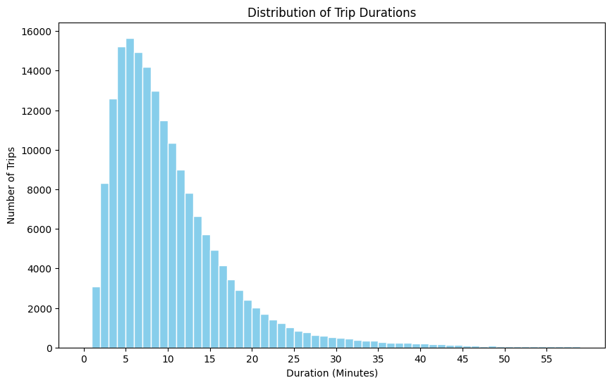

```python
## Histogram of trip durations
plt.figure(figsize=(10, 6))
plt.hist(fordgobike_df['duration_sec'], bins=np.arange(0, 3600, 60), color='skyblue', edgecolor='white')
plt.title('Distribution of Trip Durations')
plt.xlabel('Duration (Minutes)')
plt.ylabel('Number of Trips')
plt.xticks(np.arange(0, 3600, 300), labels=np.arange(0, 60, 5))
plt.show()
```

### Discuss the distribution(s) of your variable(s) of interest. Were there any unusual points? Did you need to perform any transformations?

With this information we see several people had trips under 5 minutes which could indicate that the people either had issues or the distance between the two points were really short. No transformations needed.

### Question 2: What is the full distribution of trip durations? (Histogram)

Here we identify the full range of trips and identify the mean of the data.

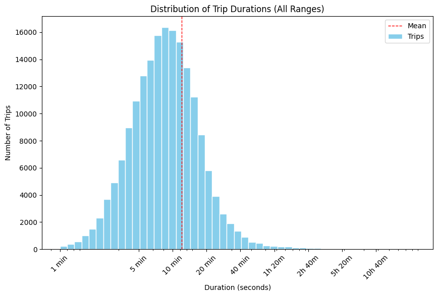

```python
# Histogram of trip durations (including longer trips)
plt.figure(figsize=(10, 6))
plt.hist(fordgobike_df['duration_sec'], bins=np.logspace(np.log10(60), np.log10(fordgobike_df['duration_sec'].max()), 50), color='skyblue', edgecolor='white')
plt.title('Distribution of Trip Durations (All Ranges)')
plt.xlabel('Duration (seconds)')
plt.ylabel('Number of Trips')
plt.xscale('log')
plt.xticks([60, 300, 600, 1200, 2400, 4800, 9600, 19200, 38400], ['1 min', '5 min', '10 min', '20 min', '40 min', '1h 20m', '2h 40m', '5h 20m', '10h 40m'], rotation=45)
plt.axvline(fordgobike_df['duration_sec'].mean(), color='red', linestyle='dashed', linewidth=1)
plt.legend(['Mean', 'Trips'])
plt.show()
```

### Discuss the distribution(s) of your variable(s) of interest. Were there any unusual points? Did you need to perform any transformations?

With this information we could look into the higher end of the trips. But at this time there is no need for transformations as we don't know the circumstances for why that tril took longer than the rest.

```python
# Find the maximum trip duration in the dataset
max_duration_sec = fordgobike_df['duration_sec'].max()
max_duration_sec
```

```
85444
```

### Question 3: What is the differences in quantity of trips taken in the week?

Here we identify amount of trips take per day within this data.

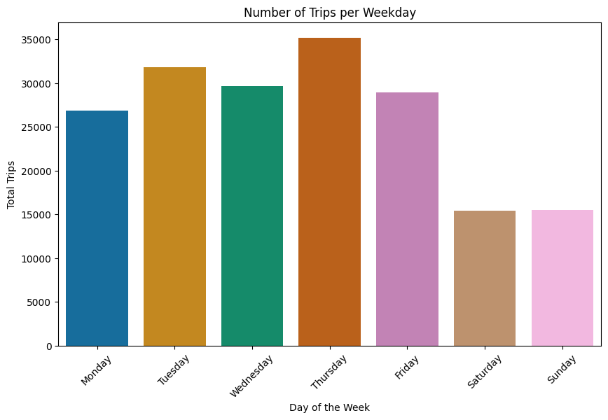

```python
# First, make sure the 'weekday' column is properly ordered as a categorical type
days_of_week = ['Monday', 'Tuesday', 'Wednesday', 'Thursday', 'Friday', 'Saturday', 'Sunday']
fordgobike_df['weekday'] = pd.Categorical(fordgobike_df['start_time'].dt.day_name(), categories=days_of_week, ordered=True)

# Now create the count plot
plt.figure(figsize=(10, 6))
sb.countplot(data=fordgobike_df, x='weekday', order=days_of_week, palette='colorblind')

plt.title('Number of Trips per Weekday')
plt.xlabel('Day of the Week')
plt.ylabel('Total Trips')
plt.xticks(rotation=45)  # Rotate the x labels for better readability if needed

plt.show()
```

### Discuss the distribution(s) of your variable(s) of interest. Were there any unusual points? Did you need to perform any transformations?

This information just provided a view of the amount of trips taken per day. No transformations needed.

## Question 4: What is the distribution of user types among the trips?

Here we identify the differences between the data identifying how many riders were subscribers or customers.

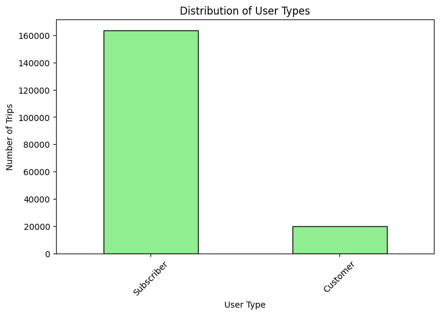

```python
# Bar chart of user types
user_type_counts = fordgobike_df['user_type'].value_counts()
plt.figure(figsize=(8, 5))
user_type_counts.plot(kind='bar', color='lightgreen', edgecolor='black')
plt.title('Distribution of User Types')
plt.xlabel('User Type')
plt.ylabel('Number of Trips')
plt.xticks(rotation=45)
plt.show()
```

### Discuss the distribution(s) of your variable(s) of interest. Were there any unusual points? Did you need to perform any transformations?

Seems to be subscribers taking interest in bikes and riding more than customers.No transformations needed.

### Of the features you investigated, were there any unusual distributions? Did you perform any operations on the data to tidy, adjust, or change the form of the data? If so, why did you do this?

Unusual distributions would be the higher and lower points of the trip start and end times and the amount difference between the two categories of subscribers and customers. Nothing that needs to be changed as of now for this data. But for future data we need to identify based on date and time the day of the week, and the time of day each trip was taken.

## Bivariate Exploration

> In this section, investigate relationships between pairs of variables in your data. Make sure the variables that you cover here have been introduced in some fashion in the previous section (univariate exploration).

> **Rubric Tip**: This part (Bivariate Exploration) should include at least one scatter plot, one box plot, and at least one clustered bar chart or heat map.

```python
# *Function to Categorize Day of week*
```

```python
def assign_day_of_week(df, datetime_col='start_time'):
    # Ensure 'start_time' is in datetime format
    df[datetime_col] = pd.to_datetime(df[datetime_col])

    # Create a new column for day of the week from 'start_time'
    df['day_of_week'] = df[datetime_col].dt.day_name()

    # Define the correct order for days of the week
    days_order = ['Monday', 'Tuesday', 'Wednesday', 'Thursday', 'Friday', 'Saturday', 'Sunday']

    # Convert 'day_of_week' to a categorical type with the specified order
    df['day_of_week'] = pd.Categorical(df['day_of_week'], categories=days_order, ordered=True)
```

```python
# *Function to Categorize Time of Day*
```

```python
def categorize_time_of_day(df, datetime_col='start_time'):
    # Inner function to categorize a single datetime object
    def get_time_category(dt):
        if 5 <= dt.hour < 12:
            return 'Morning'
        elif 12 <= dt.hour < 17:
            return 'Afternoon'
        else:
            return 'Evening'  # Adjust if you have more categories, e.g., 'Night'

    # Apply the function to each datetime object in the column
    df['period_day'] = df[datetime_col].apply(get_time_category)
    return df
```

## Question 1: What is the relationship between Trip Duration and User Type (Boxplot)

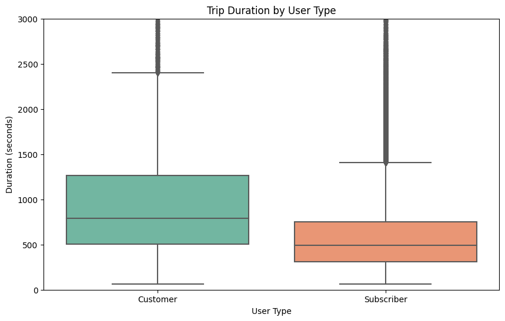

```python
plt.figure(figsize=(10, 6))
sb.boxplot(data=fordgobike_df, x='user_type', y='duration_sec', palette='Set2')
plt.title('Trip Duration by User Type')
plt.xlabel('User Type')
plt.ylabel('Duration (seconds)')
plt.ylim(0, 3000)  # Limiting duration for better visualization
plt.show()
```

## Question 2: What is the distribution of trip durations across different Days of the Week? (Boxplot)

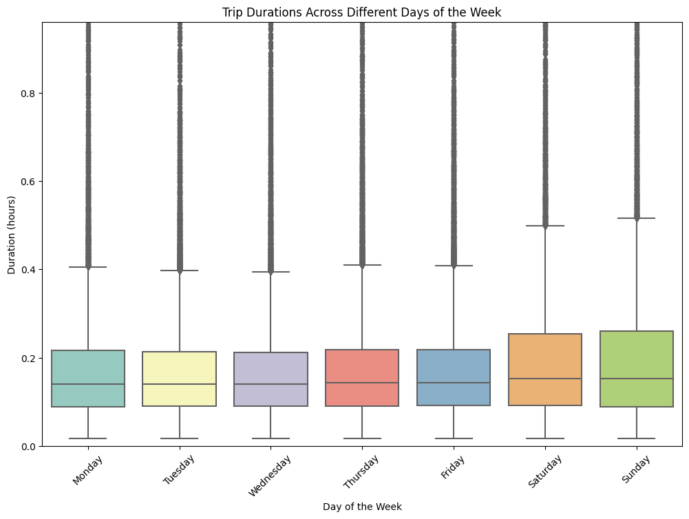

```python
# Convert duration from seconds to hours
fordgobike_df['duration_hours'] = fordgobike_df['duration_sec'] / 3600

# Convert 'start_time' to weekday
fordgobike_df['weekday'] = fordgobike_df['start_time'].dt.day_name()

plt.figure(figsize=(12, 8))

# Create the boxplot using the hour durations
sb.boxplot(data=fordgobike_df, x='weekday', y='duration_hours', palette='Set3',
           order=['Monday', 'Tuesday', 'Wednesday', 'Thursday', 'Friday', 'Saturday', 'Sunday'])

plt.title('Trip Durations Across Different Days of the Week')
plt.xlabel('Day of the Week')
plt.ylabel('Duration (hours)')
plt.ylim(0, fordgobike_df['duration_hours'].quantile(0.99))  # Limit to 99th percentile to reduce the impact of outliers
plt.xticks(rotation=45)
plt.show()
```

## Question 3: What is the number of trips by User Type across different Days of the Week? (Countplot)

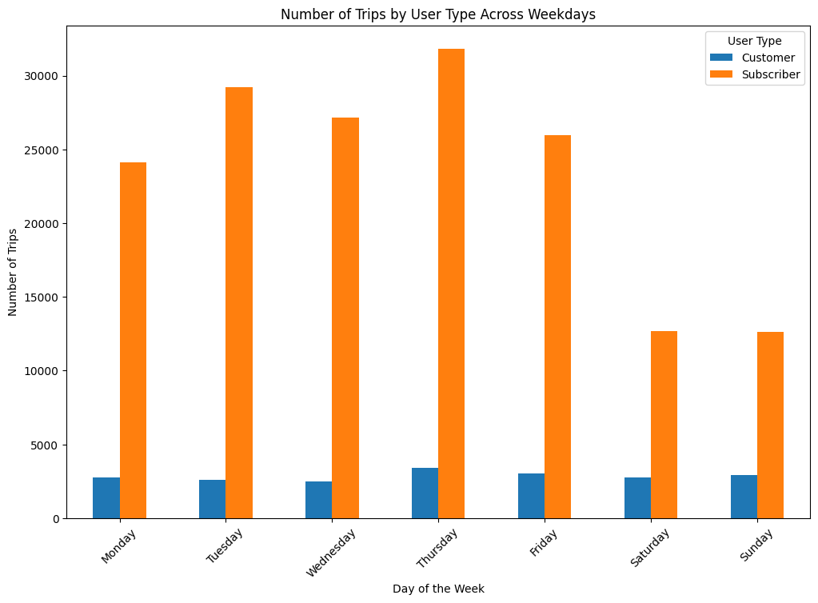

```python
# Call the function to assign day of the week with the specified order
assign_day_of_week(fordgobike_df)

# Now 'day_of_week' is in the correct order, so we can count the number of trips
trip_counts = fordgobike_df.groupby(['day_of_week', 'user_type']).size().unstack()

# Plot the counts using 'day_of_week' which is now ordered from Monday to Sunday
trip_counts.plot(kind='bar', figsize=(12, 8))
plt.title('Number of Trips by User Type Across Weekdays')
plt.xlabel('Day of the Week')
plt.ylabel('Number of Trips')
plt.xticks(rotation=45)  # Might not be needed if labels are clear
plt.legend(title='User Type')
plt.show()
```

## Question 4: What are the top 8 stations for customers and subscribers based on day? (Countplot)

```python
# Filter the DataFrame by user type for customers and subscribers
df_cust = fordgobike_df[fordgobike_df['user_type'] == 'Customer']
df_sub = fordgobike_df[fordgobike_df['user_type'] == 'Subscriber']

# Determine the top 8 stations with the most trips for the order
st_stat_order = fordgobike_df['start_station_name'].value_counts().head(8).index
```

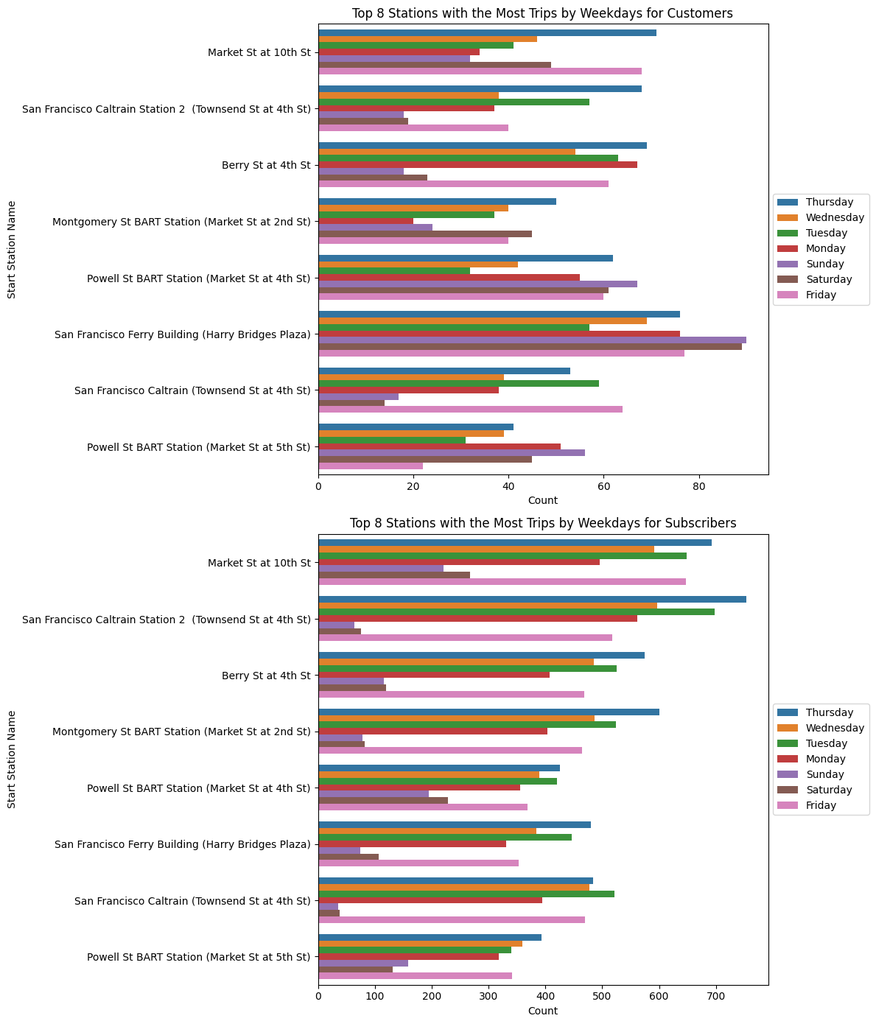

```python
plt.figure(figsize=(12, 14))

# Count plot for customers
ax1 = plt.subplot(211)
sb.countplot(data=df_cust, y='start_station_name', hue='weekday', order=st_stat_order)
plt.legend(loc='center left', bbox_to_anchor=(1, 0.5))
plt.ylabel('Start Station Name')
plt.xlabel('Count')
plt.title('Top 8 Stations with the Most Trips by Weekdays for Customers')

# Count plot for subscribers
ax2 = plt.subplot(212)
sb.countplot(data=df_sub, y='start_station_name', hue='weekday', order=st_stat_order)
plt.legend(loc='center left', bbox_to_anchor=(1, 0.5))
plt.ylabel('Start Station Name')
plt.xlabel('Count')
plt.title('Top 8 Stations with the Most Trips by Weekdays for Subscribers')
plt.tight_layout()  # Adjust layout to fit

plt.show()
```

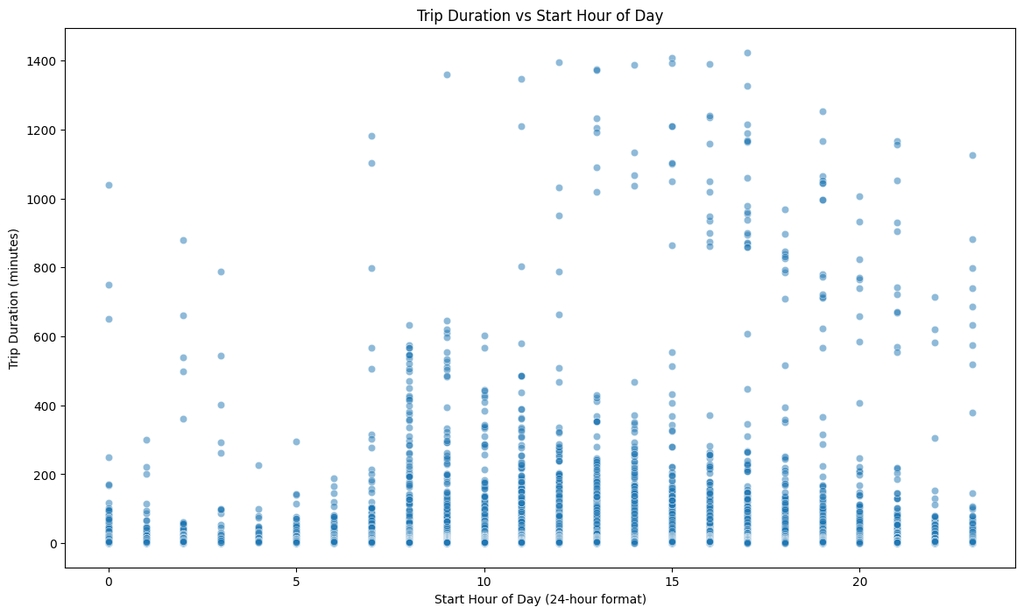

```python
# Convert 'start_time' to datetime if not already done
fordgobike_df['start_time'] = pd.to_datetime(fordgobike_df['start_time'])

# Extract the hour from 'start_time'
fordgobike_df['start_hour'] = fordgobike_df['start_time'].dt.hour

# Convert 'duration_sec' to minutes if not already done
fordgobike_df['duration_min'] = fordgobike_df['duration_sec'] / 60

# Scatter plot of trip duration against start hour of the day

plt.figure(figsize=(14, 8))

sb.scatterplot(data=fordgobike_df, x='start_hour', y='duration_min', alpha=0.5)



plt.title('Trip Duration vs Start Hour of Day')

plt.xlabel('Start Hour of Day (24-hour format)')

plt.ylabel('Trip Duration (minutes)')



plt.show()
```

### Did you observe any interesting relationships between the other features (not the main feature(s) of interest)?

The Box and whisker plot looks odd as the median time is 500 second for a bike ride which is pretty short but maybe the distance is not that far. I then used another box plot to change the range to be in increments of hours for readibility and there are still some people who went hours with the bike.

## Multivariate Exploration

> Create plots of three or more variables to investigate your data even further. Make sure that your investigations are justified, and follow from your work in the previous sections.

> **Rubric Tip**: This part (Multivariate Exploration) should include at least one Facet Plot, and one Plot Matrix or Scatterplot with multiple encodings.

> **Rubric Tip**: Think carefully about how you encode variables. Choose appropriate color schemes, markers, or even how Facets are chosen. Also, do not overplot or incorrectly plot ordinal data.

## What is the relationship of trip duration based on time of start?

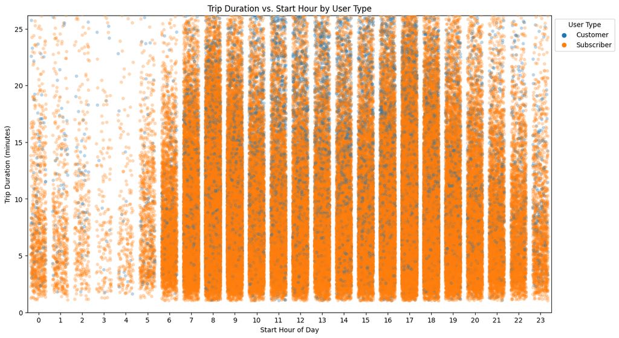

```python
# Convert duration from seconds to minutes
fordgobike_df['duration_min'] = fordgobike_df['duration_sec'] / 60

# Ensure the 'start_hour' column exists
fordgobike_df['start_hour'] = fordgobike_df['start_time'].dt.hour

plt.figure(figsize=(14, 8))


sample_df = fordgobike_df  # Use the full dataset, or replace with a sample if needed

# Use 'stripplot' for jitter. Note: 'stripplot' can be quite slow with large datasets.
sb.stripplot(data=sample_df, x='start_hour', y='duration_min', hue='user_type', alpha=0.3, jitter=0.35)

plt.title('Trip Duration vs. Start Hour by User Type')
plt.xlabel('Start Hour of Day')
plt.ylabel('Trip Duration (minutes)')

# Limiting the y-axis to focus on more common trip durations and reduce the impact of outliers
plt.ylim(0, sample_df['duration_min'].quantile(0.95))  # Adjust according to your dataset specifics

# Move the legend outside of the plot area
plt.legend(title='User Type', bbox_to_anchor=(1, 1), loc='upper left')

plt.show()
```

## What is time people started and how long did they spend biking as either a subscriber or a customer? This will be broke down by time of the day being Morning, Afternoon and Evening. (Facet Plot)

```python
def categorize_time_of_day(df, datetime_col='start_time'):
    def get_time_category(dt):
        if 5 <= dt.hour < 12:
            return 'Morning'
        elif 12 <= dt.hour < 17:
            return 'Afternoon'
        else:  # Covering evening and night
            return 'Evening'

    # Apply the function to each row based on the specified datetime column
    df['time_of_day'] = df[datetime_col].apply(get_time_category)
    return df  # Make sure to return the DataFrame

# Now call the function and pass the DataFrame
fordgobike_df = categorize_time_of_day(fordgobike_df)
```

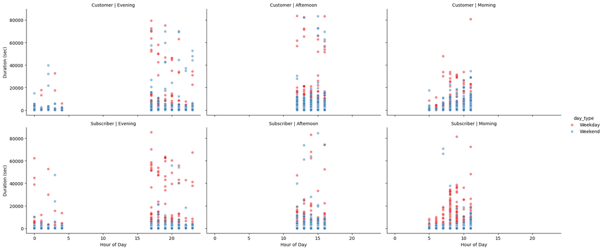

```python
def determine_day_type(df):
    # Apply a function to determine if the day is a weekday or weekend
    # 0 = Monday, 6 = Sunday
    df['day_type'] = df['start_time'].dt.dayofweek.apply(lambda x: 'Weekday' if x < 5 else 'Weekend')

# Apply the function to the dataframe
determine_day_type(fordgobike_df)

# Create the FacetGrid with 'time_of_day', 'user_type', and 'day_type'
g = sb.FacetGrid(data=fordgobike_df, col='time_of_day', row='user_type', hue='day_type', height=4, aspect=1.5, palette='Set1', legend_out=True)

# Map the scatterplot to the grid
g.map(sb.scatterplot, 'start_hour', 'duration_sec', alpha=0.5)

# Set axis labels and titles
g.set_axis_labels('Hour of Day', 'Duration (sec)')
g.set_titles(col_template="{col_name}", row_template="{row_name}")

# Add a legend
g.add_legend()

# Show the plot
plt.show()
```

### Were there any interesting or surprising interactions between features?

The issue Im seeing here is the duration_sec is so low and in order to actually see the full data set you would need a large graph or use the log function which makes it harder to explain. What was great to see was the stations that were utilized during the weekdays vs the weekends. The stripplot had to be modified to show a wider dispersment on the hour for visibility.

## Conclusions

In summary I found that the information useful in identifying the times and days to look for bikers in San Francisco. Looking at a big cities data and seeing how much they actual use bikes helped with analysis. It is useful to factor in several variables in order to get the best picture of the data. We looked into the amount of uses, duration of use, day/time, who Subscriber/Customer, and data associated. This gave valueable insight into the traffic patterns and when people choose to use the bikes. With Analysis we can make an assumption that these bikes are heavily used in the beginning of working hours and returned after work around 4-6pm.

> Remove all Tips mentioned above, before you convert this notebook to PDF/HTML.

> At the end of your report, make sure that you export the notebook as an html file from the `File > Download as... > HTML or PDF` menu. Make sure you keep track of where the exported file goes, so you can put it in the same folder as this notebook for project submission. Also, make sure you remove all of the quote-formatted guide notes like this one before you finish your report!

```python
# Save the copy to a CSV file
  #fordgobike_df.to_csv('fordgobike_df_copy.csv', index=False)
```